# Assignment 5

Maksim Nikiforov

9/15/2021

### 1.

*Read in the data and modify the variables as mentioned in the notes. Print the updated data object out.*

```r
# Read in space-separated data using "read_table()" function.
# Remove extra column of NULLs by selecting only the columns we want.
crabData <- read_table(file = "./crabs.txt", col_names = TRUE) %>% select("color", "spine", "width", "satell", "weight", "y")
# Use conditionals to overwrite color, spine, and y columns
crabData$color <- if_else(crabData$color == 2, "light",
                          if_else(crabData$color == 3, "medium",
                                  if_else(crabData$color == 4, "dark",
                                          if_else(crabData$color == 5, "darker", "undefined"))))

crabData$spine <- if_else(crabData$spine == 1, "Both Good",
                          if_else(crabData$spine == 2, "One Worn/Broken",
                                  if_else(crabData$spine == 3, "Both Worn/Broken", "Undefined")))

crabData$y <- if_else(crabData$y == 1, "At least 1 Satellite", "No Satellite")

# Convert the three variables (color, spine, y) to factors.
crabData$color <- as.factor(crabData$color)
crabData$spine <- as.factor(crabData$spine)
crabData$y <- as.factor(crabData$y)

# Print the updated data
crabData
```

```
## # A tibble: 173 × 6
##    color  spine            width satell weight y
##    <fct>  <fct>            <dbl>  <dbl>  <dbl> <fct>
##  1 medium Both Worn/Broken  28.3      8   3050 At least 1 Satellite
##  2 dark   Both Worn/Broken  22.5      0   1550 No Satellite
##  3 light  Both Good         26        9   2300 At least 1 Satellite
##  4 dark   Both Worn/Broken  24.8      0   2100 No Satellite
##  5 dark   Both Worn/Broken  26        4   2600 At least 1 Satellite
##  6 medium Both Worn/Broken  23.8      0   2100 No Satellite
##  7 light  Both Good         26.5      0   2350 No Satellite
##  8 dark   One Worn/Broken   24.7      0   1900 No Satellite
##  9 medium Both Good         23.7      0   1950 No Satellite
## 10 dark   Both Worn/Broken  25.6      0   2150 No Satellite
## # … with 163 more rows
```

### 2.

*Create a two-way contingency table between the satellite and spine variables. Write text describing what two of the numbers in the table represent.*

```r
table(crabData$spine, crabData$satell)
```

```
##
##                     0  1  2  3  4  5  6  7  8  9 10 11 12 14 15
##   Both Good        11  3  1  2  4  7  3  1  2  2  0  0  0  1  0
##   Both Worn/Broken 43 13  8 15 12  8  8  3  4  1  3  1  1  0  1
##   One Worn/Broken   8  0  0  2  3  0  2  0  0  0  0  0  0  0  0
```

### 3.

*Create a three way table between the color, spine, and satellite variables. Output the table.*

Here, we see that a medium-colored crab with both spines in “good” condition had as many as 14 satellites. Crabs with one spine worn or broken did not exceed 6 satellites.

```r
# Create a three-way table of color, spine, and satellite (CSS)
tabCSS <- table(crabData$color, crabData$satell, crabData$spine)
tabCSS
```

```
## , ,  = Both Good
##
##
##           0  1  2  3  4  5  6  7  8  9 10 11 12 14 15
##   dark    0  0  0  1  1  0  0  0  0  1  0  0  0  0  0
##   darker  1  0  0  0  0  0  0  0  0  0  0  0  0  0  0
##   light   2  0  1  0  1  1  2  0  1  1  0  0  0  0  0
##   medium  8  3  0  1  2  6  1  1  1  0  0  0  0  1  0
##
## , ,  = Both Worn/Broken
##
##
##           0  1  2  3  4  5  6  7  8  9 10 11 12 14 15
##   dark   16  5  2  5  3  2  2  1  0  0  1  0  0  0  0
##   darker 13  0  0  2  1  1  0  0  1  0  1  0  1  0  0
##   light   1  0  0  0  0  0  0  0  0  0  0  0  0  0  0
##   medium 13  8  6  8  8  5  6  2  3  1  1  1  0  0  1
##
## , ,  = One Worn/Broken
##
##
##           0  1  2  3  4  5  6  7  8  9 10 11 12 14 15
##   dark    2  0  0  1  1  0  0  0  0  0  0  0  0  0  0
##   darker  1  0  0  0  0  0  0  0  0  0  0  0  0  0  0
##   light   0  0  0  1  0  0  1  0  0  0  0  0  0  0  0
##   medium  5  0  0  0  2  0  1  0  0  0  0  0  0  0  0
```

*Then, using that table object, print out a two-way table between spine and satellite for crabs with ‘darker’ color. Write text describing what one of the numbers in the table represents.*

In the two-way table below, we see that that 13 “darker” colored crabs with both spines worn or broken had no satellites but one such crab had as many as 12 satellites. The data set also has 1 “darker” crab with both spines in good condition and 1 “darker” crab with a worn or broken spine. Neither crab has a satellite.

```r
# Identify structure of table object to determine array positions
str(tabCSS)
```

```
##  'table' int [1:4, 1:15, 1:3] 0 1 2 8 0 0 0 3 0 0 ...
##  - attr(*, "dimnames")=List of 3
##   ..$ : chr [1:4] "dark" "darker" "light" "medium"
##   ..$ : chr [1:15] "0" "1" "2" "3" ...
##   ..$ : chr [1:3] "Both Good" "Both Worn/Broken" "One Worn/Broken"
```

```r
# Return all spine and satellite information for crabs with "darker" color [2, , ]
tabCSS[2, , ]
```

```
##
##      Both Good Both Worn/Broken One Worn/Broken
##   0          1               13               1
##   1          0                0               0
##   2          0                0               0
##   3          0                2               0
##   4          0                1               0
##   5          0                1               0
##   6          0                0               0
##   7          0                0               0
##   8          0                1               0
##   9          0                0               0
##   10         0                1               0
##   11         0                0               0
##   12         0                1               0
##   14         0                0               0
##   15         0                0               0
```

### 4.

*Recreate the side-by-side bar plots. Write text that comments on any patterns you see in one of the plots.*

Medium-colored crabs are the most prevalent in this data set and the majority have at least 1 satellite.

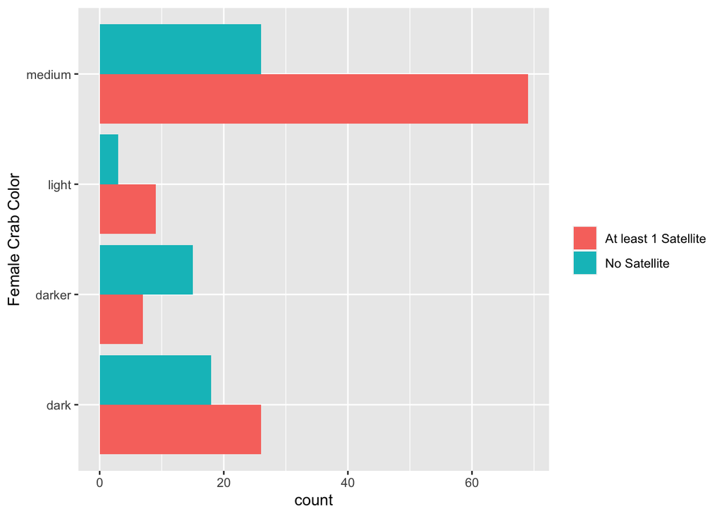

```r
g <- ggplot(data = crabData, aes(x = color))

# Set legend title with scale_fill_discrete()
g + geom_bar(aes(fill = y), position = "dodge") +
  labs(x = "Female Crab Color") +
  scale_fill_discrete(name = " ") +
  coord_flip()
```

Moreover, most crabs in the data set have spines which are both worn or broken. The number of such crabs with at least 1 satellite is nearly double the number of crabs without a satellite.

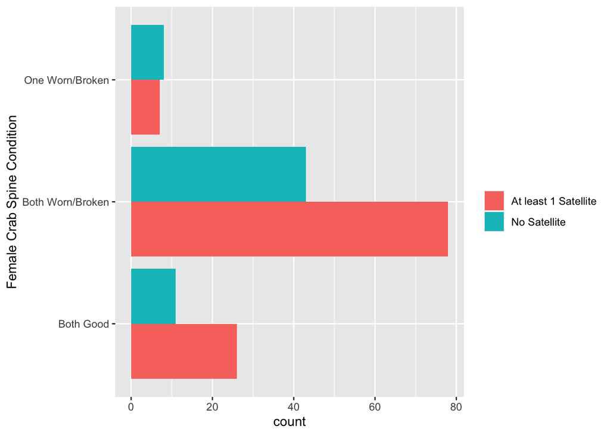

```r
g <- ggplot(data = crabData, aes(x = spine))

# Set legend title with scale_fill_discrete()
g + geom_bar(aes(fill = y), position = "dodge") +
  labs(x = "Female Crab Spine Condition") +
  scale_fill_discrete(name = " ") +
  coord_flip()
```

Medium-colored crabs outnumber other colors for all three spine conditions.

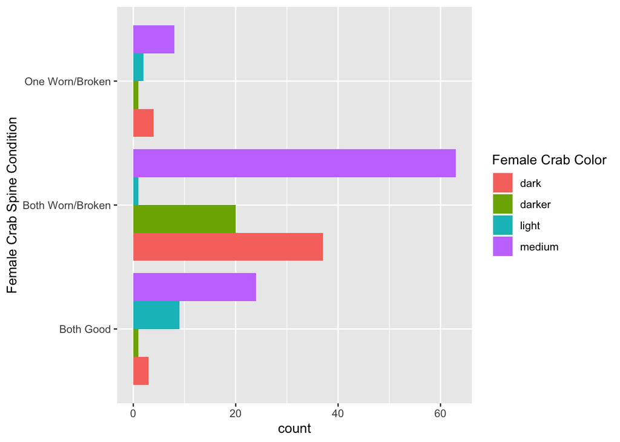

```r
g <- ggplot(data = crabData, aes(x = spine))

g + geom_bar(aes(fill = color), position = "dodge") +
  labs(x = "Female Crab Spine Condition") +
  scale_fill_discrete(name = "Female Crab Color") +
  coord_flip()
```

### 5.

*Recreate the set of side-by-side bar plots below. You’ll need to look up how to orient the x-axis labels to 45 degrees. Write text that comments on any patterns you see.*

Of the three categories of spine condition, crabs with one worn or broken spine make up the lowest number. In the category of color, medium-colored crabs outnumber all others.

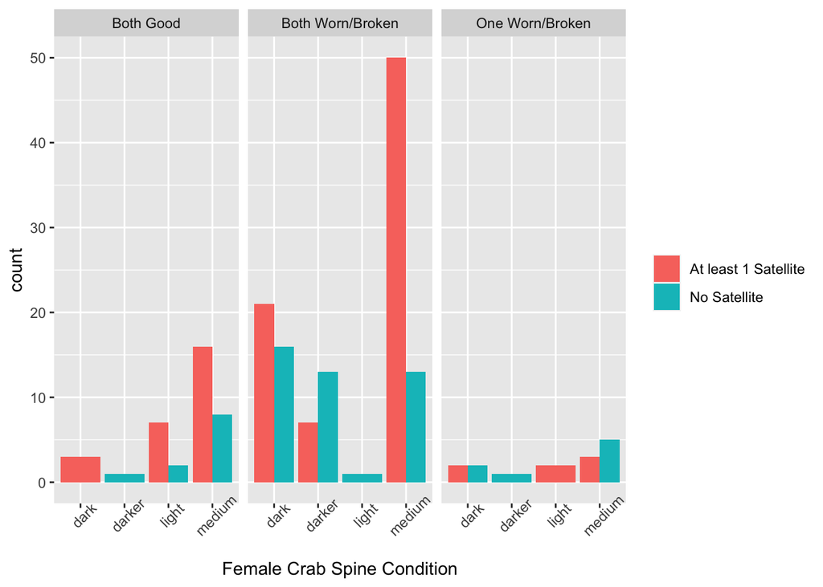

```r
g <- ggplot(data = crabData, aes(x = color))

# Use facet_wrap to divide plots into subplots
g + geom_bar(aes(fill = y), position = "dodge") +
  facet_wrap( ~ spine) +
  labs(x = "Female Crab Spine Condition") +
  scale_fill_discrete(name = " ") +
  theme(axis.text.x = element_text(angle = 45))
```

### 6.

*Recreate the summary statistics below. Write text that interprets one of the sets of summary stats.*

```r
# Group data by color/y to match assignment. Then, create and rename summary columns.
# Round numbers and arrange in descending order by color/descending y to match assignment example.
sumCrabData <- crabData %>% group_by(color, y) %>%
  summarise(Avg = round(mean(weight), 0), Sd = round(sd(weight), 0), Median = median(weight), IQR = round(IQR(weight), 0)) %>%
  arrange(color, desc(y))
sumCrabData
```

```
## # A tibble: 8 × 6
## # Groups:   color [4]
##   color  y                      Avg    Sd Median   IQR
##   <fct>  <fct>                <dbl> <dbl>  <dbl> <dbl>
## 1 dark   No Satellite          1907   348   1900   462
## 2 dark   At least 1 Satellite  2571   495   2575   719
## 3 darker No Satellite          2162   436   2150   650
## 4 darker At least 1 Satellite  2200   523   2100   200
## 5 light  No Satellite          2525   152   2600   138
## 6 light  At least 1 Satellite  2664   442   2700   650
## 7 medium No Satellite          2242   482   2200   512
## 8 medium At least 1 Satellite  2649   615   2700   800
```

### 7.

*Recreate the boxplots below. Write text that comments on any patterns you see.*

Crabs with at least 1 satellite have a higher median weight (~2,600 g) than crabs with no satellites (~2,125 g). Both plots are relatively symmetric, but the leftmost plot displays at least 1 potential outlier (exceeding past 1.5 times the IQR).

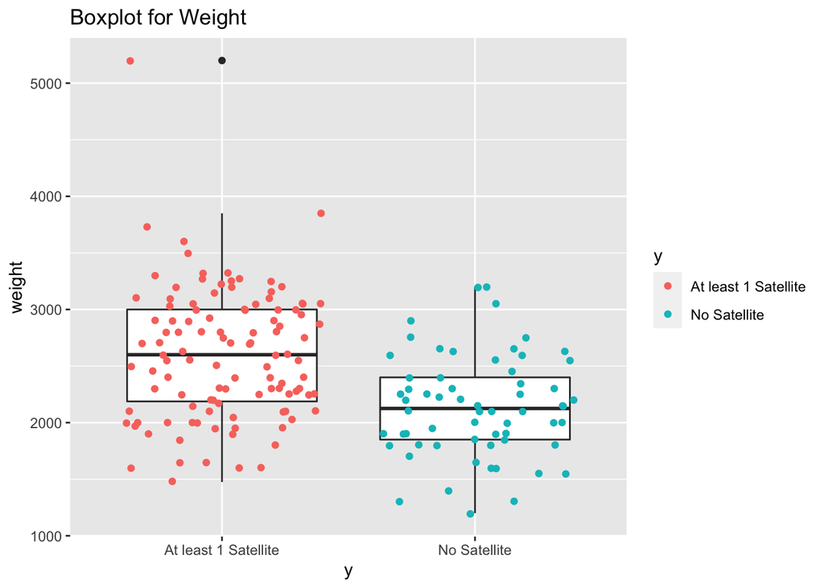

```r
# Overlay scatterplot with geom_point and position = "jitter"
g <- ggplot(crabData, aes(x = y, y = weight), position = "jitter")
g + geom_boxplot() +
  geom_point(aes(color = y), position = "jitter") +
  labs(title = "Boxplot for Weight")
```

Crabs with at least 1 satellite have a higher median width than crabs with no satellites. The leftmost plot is relatively symmetric, while the rightmost plot is slightly left skewed. As with weight, there is at least 1 potential outlier in the leftmost plot.

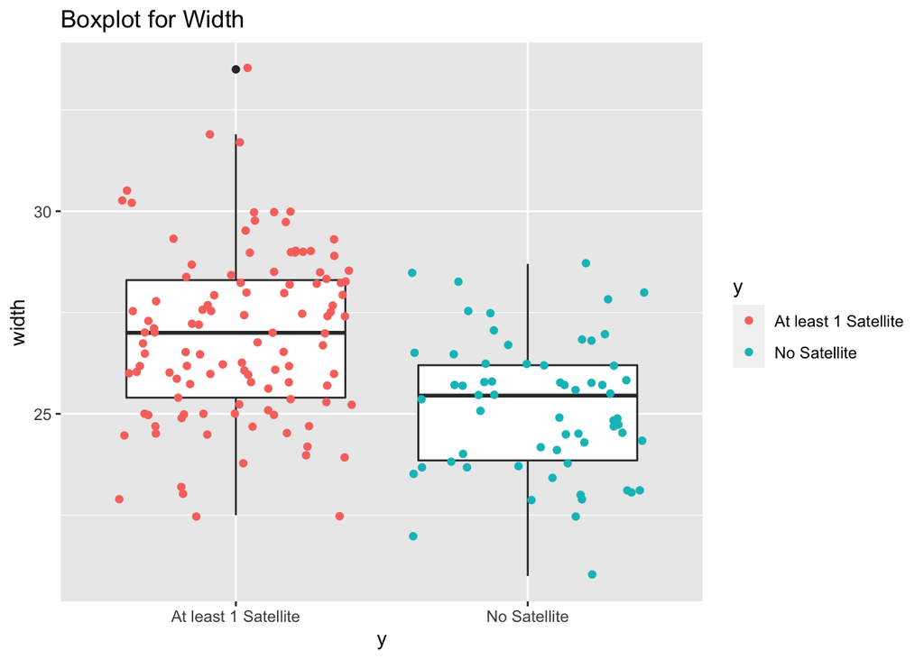

```r
g <- ggplot(crabData, aes(x = y, y = width), position = "jitter")
g + geom_boxplot(fill = "white") +
  geom_point(aes(color = y), position = "jitter") +
  labs(title = "Boxplot for Width")
```

### 8.

*Report the correlation between the weight and width variables.*

```r
# Report the correlation
cor(crabData$weight, crabData$width)
```

```
## [1] 0.8868715
```

*Then recreate the scatterplot below. Write text that comments on any patterns you see.*

Weight and width can be modeled linearly and, with a correlation value of 0.89, both variables have a high positive correlation. We see at least three outliers with a high carapace width and a low weight, and one outlier with high carapace width and a high weight.

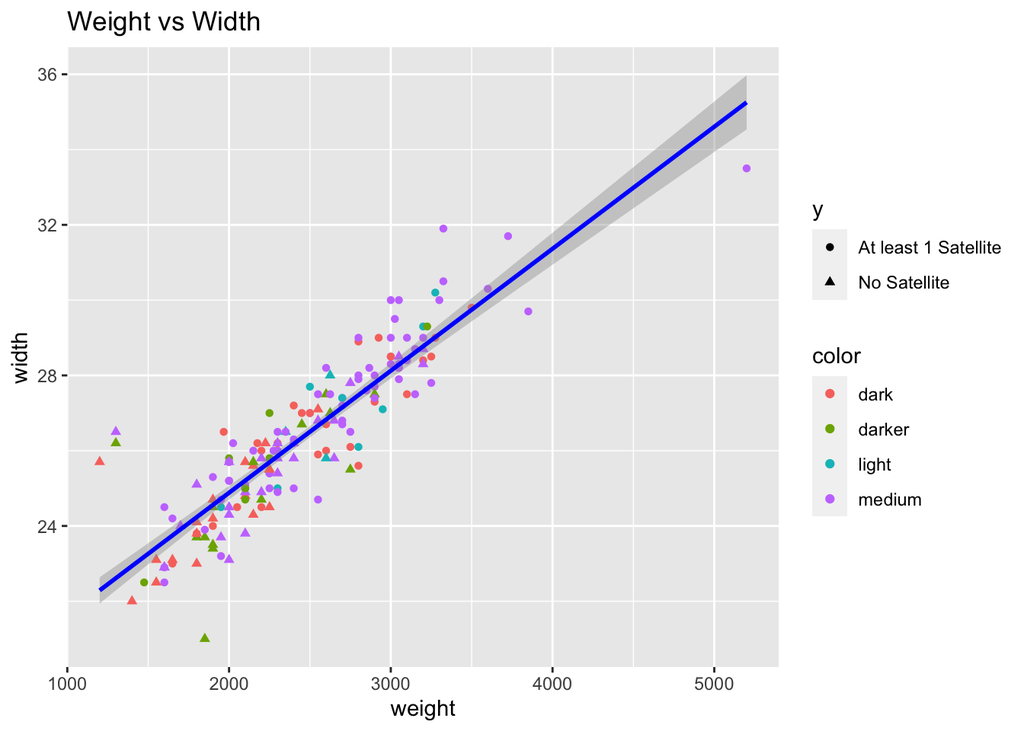

```r
# Plot regression line with geom_smooth
g <- ggplot(crabData, aes(x = weight, y = width))
g + geom_point(aes(color = color, shape = y)) +
  geom_smooth(method = lm, col = "Blue") +
  labs(title = "Weight vs Width")
```